# Jan Piotrowski Homework 4

From the first assignment, I obtained the SpeedDating imbalanced dataset with the following features:

- **pref_o_attractive**: How important does the partner rate attractiveness
- **pref_o_sincere**: How important does the partner rate sincerity
- **pref_o_intelligence**: How important does the partner rate intelligence
- **pref_o_funny**: How important does the partner rate being funny
- **pref_o_ambitious**: How important does the partner rate ambition
- **pref_o_shared_interests**: How important does the partner rate having shared interests
- **attractive_o**: Rating by the partner (about me) at the night of the event on attractiveness
- **intelligence_o**: Rating by the partner (about me) at the night of the event on intelligence
- **funny_o**: Rating by the partner (about me) at the night of the event on being funny
- **shared_interests_o**: Rating by the partner (about me) at the night of the event on shared interest
- **attractive_important**: What do you look for in a partner - attractiveness
- **sincere_important**: What do you look for in a partner - sincerity
- **intellicence_important**: What do you look for in a partner - intelligence
- **funny_important**: What do you look for in a partner - being funny
- **ambtition_important**: What do you look for in a partner - ambition
- **shared_interests_important**: What do you look for in a partner - shared interests
- **interests_correlate**: Correlation between participant’s and partner’s ratings of interests.
- **like**: Did you like your partner?
- **TARGET**: Match or not.

This is interesting because the most important feature should be *like*, but the model can provide other insights.

I retrieved models from the first Homework: Logistic Regression and XGBoost.

## Empirical distribiution

Based on Piotr Golach HW3 I checked empirical distribuion for the dataset.

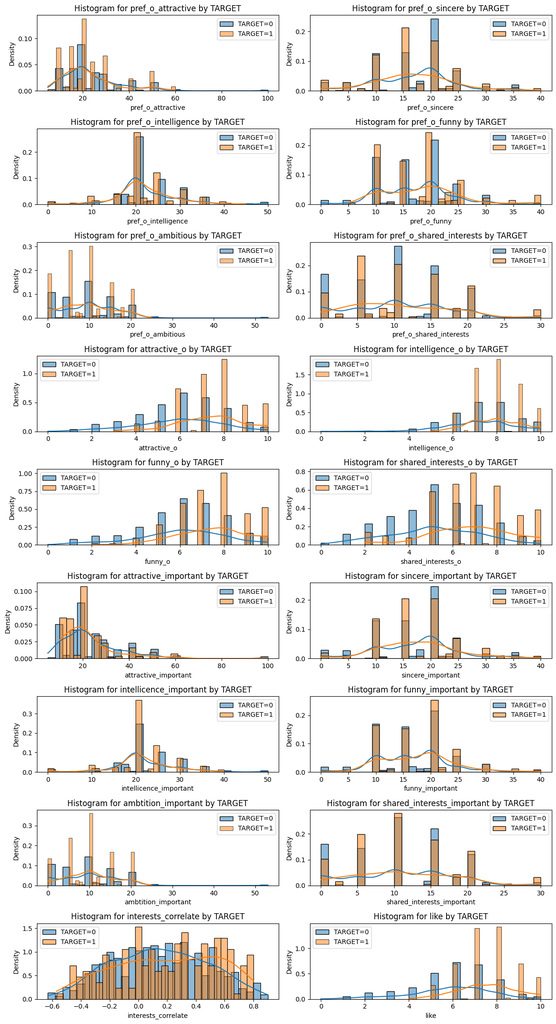

```python
fig, axes = plt.subplots(9, 2, figsize=(12, 22))

axes = axes.ravel()

for i, col in enumerate(df.columns):
    if col != "TARGET":
        sns.histplot(df[df['TARGET'] == 0][col], bins=30, label='TARGET=0', stat='density', kde=True, ax=axes[i])
        sns.histplot(df[df['TARGET'] == 1][col], bins=30, label='TARGET=1', stat='density', kde=True, ax=axes[i])
        axes[i].set_title(f'Histogram for {col} by TARGET')
        axes[i].legend()

for j in range(i+1, len(axes)):
    fig.delaxes(axes[j])

plt.tight_layout()
plt.show()
```

We can see that distribiuton of features isn't very skewed for 'importance' features, but it's differ for features with opinion (attractive, like, intelligence). This is quite intuitive - people rate importance independent of other person, and rate their opinion about second person based on Target - if they would date again this person.

# SHAP comparision of two observations

```python
bd_obs_1.plot(bd_interactions_obs_1)
```

[output not shown]

```python
bd_obs_3.plot(bd_interactions_obs_3)
```

[output not shown]

The insights are more clear for me than for LIME. For example from 'attractive importance = 10 decreases average response by 0.081, we can conclude that people who rate importance of attractivens very low are more likely to reject candidates.

## Differences between packages

```python
bd_obs_1.plot(bd_interactions_obs_1)
```

[output not shown]

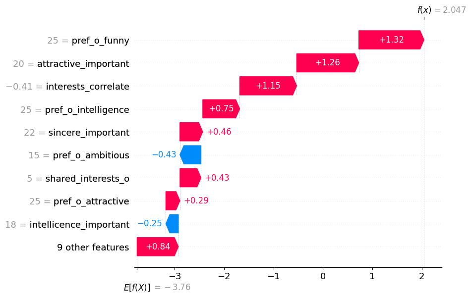

```python
shap.plots.waterfall(explainer_shap(X_train.iloc[:1])[0])
```

## Logistic regression

```python
bd_obsn.plot(bd_interactions_obs_n)
```

[output not shown]

```python
bd_obsn_lr.plot(bd_interactions_obs_n_lr)
```

[output not shown]

# Appendix

```python
import os'


while 'Homeworks' in os.getcwd():
    os.chdir('..')
```

[output not shown]

```python
import warnings
warnings.filterwarnings("ignore", category=DeprecationWarning)
```

```python
# pip install pandas matplotlib scikit-learn xgboost plotly lime seaborn dalex
import requests
import pandas as pd
import matplotlib.pyplot as plt
import xgboost as xgb
import dalex
import shap
import seaborn as sns
import random

from sklearn.metrics import roc_auc_score, roc_curve
from sklearn.model_selection import train_test_split
```

```python
url = 'https://raw.githubusercontent.com/adrianstando/imbalanced-benchmarking-set/main/datasets/SpeedDating.csv'
response = requests.get(url)
if response.status_code == 200:
    with open('SpeedDating.csv', 'wb') as f:
        f.write(response.content)
else:
    print(f"Failed to download the file. Status code: {response.status_code}")

path = "SpeedDating.csv"
# first column is the index
df = pd.read_csv(path, index_col=0)
df
```

|  | pref_o_attractive | pref_o_sincere | pref_o_intelligence | pref_o_funny | pref_o_ambitious | pref_o_shared_interests | attractive_o | intelligence_o | funny_o | shared_interests_o | attractive_important | sincere_important | intellicence_important | funny_important | ambtition_important | shared_interests_important | interests_correlate | like | TARGET |
| --- | --- | --- | --- | --- | --- | --- | --- | --- | --- | --- | --- | --- | --- | --- | --- | --- | --- | --- | --- |
| 0 | 35.0 | 20.0 | 20.0 | 20.0 | 0.0 | 5.0 | 6.0 | 8.0 | 8.0 | 6.0 | 15.0 | 20.0 | 20.0 | 15.0 | 15.0 | 15.0 | 0.14 | 7.0 | 0 |
| 1 | 60.0 | 0.0 | 0.0 | 40.0 | 0.0 | 0.0 | 7.0 | 10.0 | 7.0 | 5.0 | 15.0 | 20.0 | 20.0 | 15.0 | 15.0 | 15.0 | 0.54 | 7.0 | 0 |
| 3 | 30.0 | 5.0 | 15.0 | 40.0 | 5.0 | 5.0 | 7.0 | 9.0 | 8.0 | 8.0 | 15.0 | 20.0 | 20.0 | 15.0 | 15.0 | 15.0 | 0.61 | 7.0 | 1 |
| 4 | 30.0 | 10.0 | 20.0 | 10.0 | 10.0 | 20.0 | 8.0 | 9.0 | 6.0 | 7.0 | 15.0 | 20.0 | 20.0 | 15.0 | 15.0 | 15.0 | 0.21 | 6.0 | 1 |
| 5 | 50.0 | 0.0 | 30.0 | 10.0 | 0.0 | 10.0 | 7.0 | 8.0 | 8.0 | 7.0 | 15.0 | 20.0 | 20.0 | 15.0 | 15.0 | 15.0 | 0.25 | 6.0 | 0 |
| ... | ... | ... | ... | ... | ... | ... | ... | ... | ... | ... | ... | ... | ... | ... | ... | ... | ... | ... | ... |
| 1836 | 15.0 | 15.0 | 20.0 | 25.0 | 10.0 | 15.0 | 2.0 | 6.0 | 2.0 | 1.0 | 25.0 | 10.0 | 20.0 | 20.0 | 10.0 | 15.0 | 0.35 | 5.0 | 0 |
| 1837 | 15.0 | 15.0 | 25.0 | 25.0 | 15.0 | 5.0 | 4.0 | 8.0 | 3.0 | 2.0 | 25.0 | 10.0 | 20.0 | 20.0 | 10.0 | 15.0 | 0.45 | 5.0 | 0 |
| 1838 | 20.0 | 20.0 | 20.0 | 20.0 | 10.0 | 10.0 | 5.0 | 4.0 | 5.0 | 3.0 | 25.0 | 10.0 | 20.0 | 20.0 | 10.0 | 15.0 | 0.13 | 5.0 | 0 |
| 1840 | 15.0 | 15.0 | 25.0 | 25.0 | 20.0 | 0.0 | 4.0 | 7.0 | 3.0 | 0.0 | 25.0 | 10.0 | 20.0 | 20.0 | 10.0 | 15.0 | 0.54 | 5.0 | 0 |
| 1843 | 10.0 | 10.0 | 35.0 | 35.0 | 8.0 | 2.0 | 7.0 | 6.0 | 5.0 | 2.0 | 25.0 | 10.0 | 20.0 | 20.0 | 10.0 | 15.0 | 0.54 | 5.0 | 0 |

1048 rows × 19 columns

## Empirical distribiutions (based on Piotr Golach HW3)

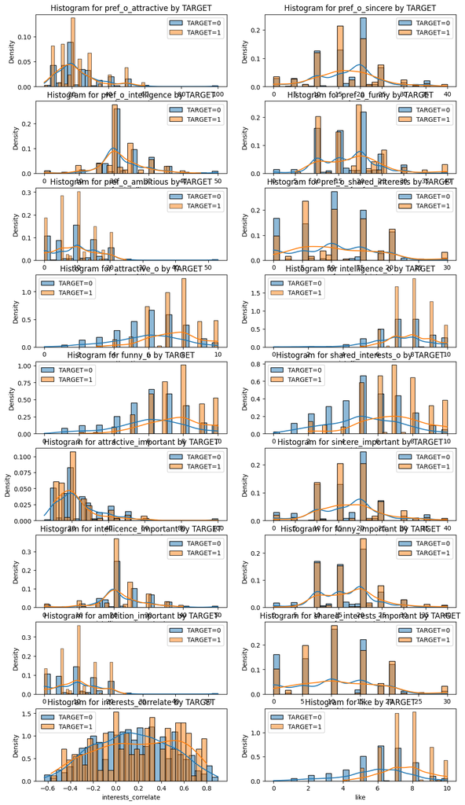

```python
fig, axes = plt.subplots(9, 2, figsize=(12, 22))

axes = axes.ravel()

for i, col in enumerate(df.columns):
    if col != "TARGET":
        sns.histplot(df[df['TARGET'] == 0][col], bins=30, label='TARGET=0', stat='density', kde=True, ax=axes[i])
        sns.histplot(df[df['TARGET'] == 1][col], bins=30, label='TARGET=1', stat='density', kde=True, ax=axes[i])
        axes[i].set_title(f'Histogram for {col} by TARGET')
        axes[i].legend()

for j in range(i+1, len(axes)):
    fig.delaxes(axes[j])

plt.tight_layout()
plt.show()
```

```python
# train test split
random.seed(42)
train, test = train_test_split(df, test_size=0.8)
X_train, y_train = train.drop(columns=['TARGET']), train['TARGET']
X_test, y_test = test.drop(columns=['TARGET']), test['TARGET']
len(X_train), len(X_test)
```

```
(209, 839)
```

```python
# Train and evaluate XGBoost
clf_xgboost = xgb.XGBClassifier()
clf_xgboost.fit(X_train, y_train)

y_pred_xgboost = clf_xgboost.predict_proba(X_test)[:, 1]
```

```python
# select two observations from the dataset
obs1_x, obs1_y = X_test.iloc[0], y_test.iloc[0]
obs2_x, obs2_y = X_test.iloc[1], y_test.iloc[1]
obs1_y, obs2_y
```

```
(0, 0)
```

```python
# calculate the model's prediction
pred1 = clf_xgboost.predict_proba(obs1_x.values.reshape(1, -1))[0][1]
pred2 = clf_xgboost.predict_proba(obs2_x.values.reshape(1, -1))[0][1]
pred1, pred2
```

```
(0.016571179, 0.0073159635)
```

```python
# Next, for the same observations, calculate the decomposition of predictions, so-called variable attributions, using SHAP from two packages: dalex and shap
explainer_dalex = dalex.Explainer(clf_xgboost, X_train, y_train, label="XGBoost")

bd_obs_1 = explainer_dalex.predict_parts(obs1_x, type='break_down', label="obs1")
bd_interactions_obs_1 = explainer_dalex.predict_parts(obs1_x, type='break_down_interactions', label="Obs1+")
```

[output not shown]

[output not shown]

[output cut: 127 more lines]

```python
bd_obs_1.plot(bd_interactions_obs_1)
```

[output not shown]

```python
explainer_dalex = dalex.Explainer(clf_xgboost, X_train, y_train, label="XGBoost")

bd_obs_2 = explainer_dalex.predict_parts(obs2_x, type='break_down', label="obs2")
bd_interactions_obs_2 = explainer_dalex.predict_parts(obs2_x, type='break_down_interactions', label="Obs2+")
```

[output not shown]

[output not shown]

[output cut: 556 more lines]

[output not shown]

```python
bd_obs_2.plot(bd_interactions_obs_2)
```

[output not shown]

```python
# explain with shap
explainer_shap = shap.Explainer(clf_xgboost, X_train)
shap_values_obs1 = explainer_shap(obs1_x)
shap_values_obs2 = explainer_shap(obs2_x)
```

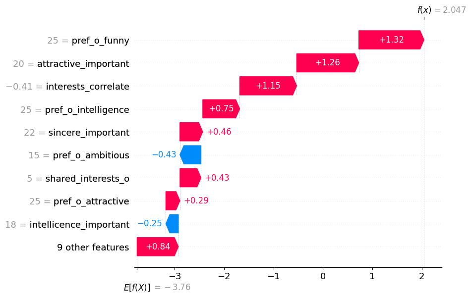

```python
shap.plots.waterfall(explainer_shap(X_train.iloc[:1])[0])
```

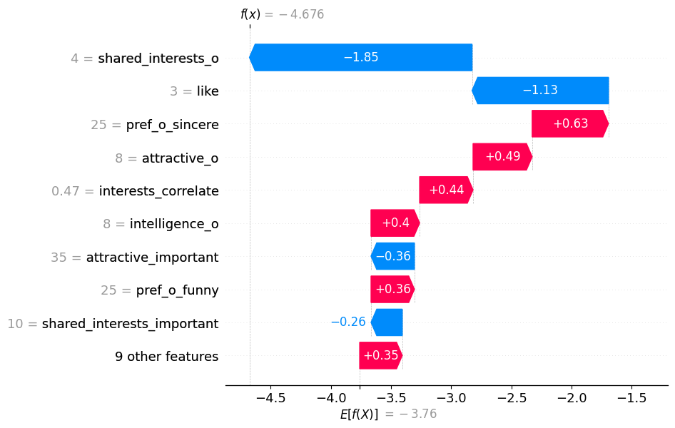

```python
shap.plots.waterfall(explainer_shap(X_train.iloc[1:2])[0])
```

```python
# finding sample with other feature than attractive importance on the first place
sample_number = 11
obs3_x, obs3_y = X_test.iloc[sample_number], y_test.iloc[sample_number]
explainer_dalex = dalex.Explainer(clf_xgboost, X_train, y_train, label="XGBoost")

bd_obs_3 = explainer_dalex.predict_parts(obs3_x, type='break_down', label="obs3")
bd_interactions_obs_3 = explainer_dalex.predict_parts(obs3_x, type='break_down_interactions', label="Obs3+")
bd_obs_3.plot(bd_interactions_obs_3)
```

[output not shown]

[output not shown]

[output cut: 556 more lines]

[output not shown]

```python
# (If possible) Select one variable X and find two observations in the dataset such that for one observation, X has a positive attribution, and for the other observation, X has a negative attribution.
# shared interets for obs2 and obs3
```

```python
# (How) Do the results differ across the two packages selected in point (3)?
# They differ a little, because the results aren't calculated dokładnie tylko to jakaś aproksymacja
```

```python
# Train and evaluate logistic regression from sklearn
from sklearn.linear_model import LogisticRegression
clf_logistic_regression = LogisticRegression()
clf_logistic_regression.fit(X_train.values, y_train.values)
```

```python
explainer_dalex = dalex.Explainer(clf_logistic_regression, X_train, y_train, label="Logistic Regression")

bd_obs_1 = explainer_dalex.predict_parts(obs1_x, type='break_down', label="obs1 LReg")
bd_interactions_obs_1 = explainer_dalex.predict_parts(obs1_x, type='break_down_interactions', label="Obs1+ LReg")
bd_obs_1.plot(bd_interactions_obs_1)
```

[output not shown]

[output not shown]

[output cut: 1480 more lines]

[output not shown]

```python
# finding sample with other feature than attractive importance on the first place
sample_number = 11
obsn_x = X_test.iloc[sample_number]
explainer_dalex = dalex.Explainer(clf_xgboost, X_train, y_train, label="XGBoost")
explainer_dalex_lr = dalex.Explainer(clf_logistic_regression, X_train, y_train, label="LR")

bd_obsn = explainer_dalex.predict_parts(obsn_x, type='break_down', label="obsn XGBoost")
bd_interactions_obs_n = explainer_dalex.predict_parts(obsn_x, type='break_down_interactions', label="Obsn XGBoost")
bd_obsn.plot(bd_interactions_obs_n)
```

[output not shown]

[output not shown]

[output cut: 564 more lines]

[output not shown]

```python
bd_obsn_lr = explainer_dalex_lr.predict_parts(obsn_x, type='break_down', label="Logistic Regression")
bd_interactions_obs_n_lr = explainer_dalex_lr.predict_parts(obsn_x, type='break_down_interactions', label="Logistic Regression")
bd_obsn_lr.plot(bd_interactions_obs_n_lr)
```

[output not shown]

[output cut: 1472 more lines]

[output not shown]